# Meta-analysis of politeness data

Bodo

07/02/2021

## Introduction

Load packages:

```r
library(tidyverse)
library(brms)
```

For reproducibility:

```r
R.Version()
```

```
## $platform
## [1] "x86_64-apple-darwin17.0"
##
## $arch
## [1] "x86_64"
##
## $os
## [1] "darwin17.0"
##
## $system
## [1] "x86_64, darwin17.0"
##
## $status
## [1] ""
##
## $major
## [1] "4"
##
## $minor
## [1] "0.2"
##
## $year
## [1] "2020"
##
## $month
## [1] "06"
##
## $day
## [1] "22"
##
## $`svn rev`
## [1] "78730"
##
## $language
## [1] "R"
##
## $version.string
## [1] "R version 4.0.2 (2020-06-22)"
##
## $nickname
## [1] "Taking Off Again"
```

```r
packageVersion('tidyverse')
```

```
## [1] '1.3.0'
```

```r
packageVersion('brms')
```

```
## [1] '2.14.4'
```

Load data:

```r
pol <- read_delim('../data/f0measures_2021-Mar-04.txt', delim = '\t')
```

## Preprocessing and data sanity checks

How many speakers?

```r
unique(pol$speaker)
```

```
##   [1] "C10"  "C11"  "C12"  "C13"  "C14"  "C15"  "C16"  "C17"  "C18"  "C19"
##  [11] "C1"   "C20"  "C2"   "C3"   "C4"   "C5"   "C6"   "C7"   "C8"   "C9"
##  [21] "M1"   "M2"   "M3"   "M4"   "M5"   "M6"   "M7"   "M8"   "JF11" "JF13"
##  [31] "JF14" "JF17" "JF18" "JF20" "JF2"  "JF3"  "JF5"  "JF6"  "JF7"  "JF8"
##  [41] "JM10" "JM12" "JM15" "JM16" "JM19" "JM1"  "JM4"  "JM9"  "KF1"  "KF2"
##  [51] "KF3"  "KF4"  "KF5"  "KF6"  "KF7"  "KF8"  "KF9"  "KM1"  "KM2"  "KM3"
##  [61] "KM4"  "KM5"  "KM6"  "KM7"  "GF01" "GF02" "GF03" "GF04" "GF05" "GF06"
##  [71] "GF07" "GF08" "GF09" "GF10" "GF11" "GM01" "GM02" "RM1"  "RF1"  "RF2"
##  [81] "RF3"  "RF4"  "RF5"  "AF01" "AF02" "AF03" "AF04" "AF06" "AF07" "AF08"
##  [91] "AF09" "AM01" "AM02" "AM03" "AM04" "AM05" "AM06" "AM07" "AM08" "AM09"
## [101] "AM10"
```

How many languages?

```r
unique(pol$lang)
```

```
## [1] "Catalan"  "Chinese"  "Japanese" "Korean"   "German"   "Russian"  "Austrian"
```

How many speakers per language:

```r
spks_count <- pol %>%
  count(speaker, lang) %>%
  select(-n) %>% count(lang)

spks_count
```

```
## # A tibble: 7 x 2
##   lang         n
## * <chr>    <int>
## 1 Austrian    18
## 2 Catalan     20
## 3 Chinese      8
## 4 German      13
## 5 Japanese    20
## 6 Korean      16
## 7 Russian      6
```

Check gender labels.

```r
unique(pol$gend)
```

```
## [1] "female" "male"
```

How many gender per language?

```r
pol %>% count(lang, speaker, gend) %>% count(lang, gend)
```

```
## # A tibble: 13 x 3
##    lang     gend       n
##    <chr>    <chr>  <int>
##  1 Austrian female     8
##  2 Austrian male      10
##  3 Catalan  female    20
##  4 Chinese  female     4
##  5 Chinese  male       4
##  6 German   female    11
##  7 German   male       2
##  8 Japanese female    12
##  9 Japanese male       8
## 10 Korean   female     9
## 11 Korean   male       7
## 12 Russian  female     5
## 13 Russian  male       1
```

Check item identifiers:

```r
unique(pol$item)
```

```
##   [1] "I1"           "I2"           "I3"           "I4"           "I5"
##   [6] "IC"           "1_8_con_1"    "1_9_con_1"    "1_7_con_1"    "1_4_con_1"
##  [11] "1_10_con_1"   "1_6_con_1"    "1_2_con_1"    "1_5_con_1"    "1_1_con_1"
##  [16] "1_3_con_1"    "1_9_con_2"    "1_4_con_2"    "1_5_con_2"    "1_7_con_2"
##  [21] "1_6_con_2"    "1_2_con_2"    "1_1_con_2"    "1_10_con_2"   "1_1_con_3"
##  [26] "1_5_con_3"    "1_10_con_3"   "1_2_con_3"    "1_8_con_3"    "1_9_con_3"
##  [31] "1_6_con_3"    "1_7_con_3"    "1_3_con_3"    "1_4_pan_1"    "1_5_pan_1"
##  [36] "1_8_pan_1"    "1_7_pan_1"    "1_6_pan_1"    "1_10_pan_1"   "1_3_pan_1"
##  [41] "1_2_pan_1"    "1_1_pan_1"    "1_7_pan_2"    "1_3_pan_2"    "1_2_pan_2"
##  [46] "1_4_pan_2"    "1_6_pan_2"    "1_5_pan_2"    "1_10_pan_2"   "1_1_pan_2"
##  [51] "1_8_pan_2"    "1_8_pan_3"    "1_5_pan_3"    "1_2_pan_3"    "1_7_pan_4"
##  [56] "1_10_pan_3"   "1_3_pan_3"    "1_4_pan_3"    "1_9_pan_3"    "1_1_pan_3"
##  [61] "1_6_pan_3"    "2_2_con_1"    "2_5_con_1"    "2_7_con_1"    "2_6_con_1"
##  [66] "2_8_con_1"    "2_9_con_1"    "2_10_con_1"   "2_1_con_1"    "2_4_con_1"
##  [71] "2_3_con_1"    "2_6_con_2"    "2_7_con_2"    "2_10_con_2"   "2_9_con_2"
```

[output cut: 87 more lines]

Get rid of news and note task:

```r
pol <- filter(pol,
              !str_detect(item, 'note'))
```

## Standardize item labels

Fix the items. We need two things:

1. polite and informal pairs of each item need the same identifier
2. items from different languages need to have different identifiers

Create new item column:

```r
pol$item_fixed <- pol$item
```

For Austrian and German, we need to get rid of a/b:

```r
ids <- pol$lang == 'Austrian' | pol$lang == 'German'
pol[ids, ]$item_fixed <- str_replace(pol[ids, ]$item_fixed, 'a|b', '')
```

For Chinese, the identifiers are “1_8_con_1” and the second element is the item:

```r
ids <- pol$lang == 'Chinese'
pol[ids, ]$item_fixed <- str_split(pol[ids, ]$item_fixed, '_', simplify = TRUE)[, 2]
```

For Korean, the structure is “I1_1”, “I1_2” and we just need to get the first bit.

```r
ids <- pol$lang == 'Korean'
pol[ids, ]$item_fixed <- str_split(pol[ids, ]$item_fixed, '_', simplify = TRUE)[, 1]
```

For Russian the structure is “dct_2_1_pol” and we need to get the second element:

```r
ids <- pol$lang == 'Russian'
pol[ids, ]$item_fixed <- str_split(pol[ids, ]$item_fixed, '_', simplify = TRUE)[, 2]
```

Next, merge language with item:

```r
pol <- mutate(pol,
              unique_item = str_c(lang, '_', item_fixed))
```

Check item identifiers:

```r
unique(pol$unique_item)
```

```
##  [1] "Catalan_I1"  "Catalan_I2"  "Catalan_I3"  "Catalan_I4"  "Catalan_I5"
##  [6] "Catalan_IC"  "Chinese_8"   "Chinese_9"   "Chinese_7"   "Chinese_4"
## [11] "Chinese_10"  "Chinese_6"   "Chinese_2"   "Chinese_5"   "Chinese_1"
## [16] "Chinese_3"   "Japanese_I1" "Japanese_I2" "Japanese_I3" "Japanese_I4"
## [21] "Japanese_I5" "Japanese_I6" "Korean_I1"   "Korean_I2"   "Korean_I3"
## [26] "Korean_I4"   "Korean_I5"   "German_12"   "German_11"   "German_1"
## [31] "German_2"    "German_3"    "German_4"    "German_5"    "German_6"
## [36] "Russian_1"   "Russian_2"   "Russian_3"   "Russian_4"   "Russian_5"
## [41] "Russian_6"   "Russian_7"   "Austrian_12" "Austrian_11" "Austrian_1"
## [46] "Austrian_2"  "Austrian_3"  "Austrian_4"  "Austrian_5"  "Austrian_6"
```

How many items per language?

```r
pol %>% count(lang, unique_item) %>% count(lang)
```

```
## # A tibble: 7 x 2
##   lang         n
## * <chr>    <int>
## 1 Austrian     8
## 2 Catalan      6
## 3 Chinese     10
## 4 German       8
## 5 Japanese     6
## 6 Korean       5
## 7 Russian      7
```

## Descriptive statistics:

Compute the average mean:

```r
pol %>% group_by(inform) %>%
  summarize(M = mean(f0md, na.rm = TRUE)) %>%
  pivot_wider(values_from = M,
              names_from = inform)
```

```
## # A tibble: 1 x 2
##   inform   pol
##    <dbl> <dbl>
## 1   192.  189.
```

For each language compute mean F0 per politeness category:

```r
lang_avgs <- pol %>% group_by(lang, inform) %>%
  summarize(M = mean(f0md, na.rm = TRUE)) %>%
  pivot_wider(values_from = M,
              names_from = inform) %>%
  mutate(diff = pol - inform)
# Show table:

lang_avgs
```

```
## # A tibble: 7 x 4
## # Groups:   lang [7]
##   lang     inform   pol   diff
##   <chr>     <dbl> <dbl>  <dbl>
## 1 Austrian   163.  159.  -3.90
## 2 Catalan    217.  211.  -5.07
## 3 Chinese    183.  181.  -1.27
## 4 German     216.  212.  -4.34
## 5 Japanese   190.  188.  -1.76
## 6 Korean     203.  192. -10.9
## 7 Russian    214.  208.  -5.68
```

Check how many speakers lower their F0 in the polite condition:

```r
spk_avgs <- pol %>%
  group_by(lang, speaker, inform) %>%
  summarize(M = mean(f0md, na.rm = TRUE)) %>%
  pivot_wider(values_from = M,
              names_from = inform) %>%
  mutate(diff = pol - inform)
```

How many lowered per language?

```r
spk_lowered <- spk_avgs %>%
  mutate(direction = ifelse(diff < 0, 1, 0)) %>% # 1 = lower
  group_by(lang) %>%
  summarize(N_lowered = sum(direction))

spk_lowered <- left_join(spk_lowered, spks_count)
spk_lowered <- mutate(spk_lowered,
                      prop_lowered = N_lowered / n,
                      prop_lowered = round(prop_lowered, 2))

# Show table:

spk_lowered
```

```
## # A tibble: 7 x 4
##   lang     N_lowered     n prop_lowered
##   <chr>        <dbl> <int>        <dbl>
## 1 Austrian        13    18         0.72
## 2 Catalan         16    20         0.8
## 3 Chinese          3     8         0.38
## 4 German           9    13         0.69
## 5 Japanese        14    20         0.7
## 6 Korean          15    16         0.94
## 7 Russian          5     6         0.83
```

```r
# Write table:

write_csv(spk_lowered, file = '../tables/proportion_lowered.csv')
```

Overall number of speakers that lowered:

```r
spk_avgs %>% ungroup() %>%
  mutate(direction = ifelse(diff < 0, 1, 0)) %>%
  summarize(N_lowered = sum(direction))
```

```
## # A tibble: 1 x 1
##   N_lowered
##       <dbl>
## 1        75
```

Compare this to total number of speakers:

```r
nrow(spk_avgs)
```

```
## [1] 101
```

## Inferential stats:

For parallel processing:

```r
options(mc.cores=parallel::detectCores())
```

Set MCMC controls for convergence:

```r
mcmc_controls <- list(adapt_delta = 0.99,
                      max_treedepth = 14)
```

```r
priors <- c(prior(normal(0, 10), class = b))
```

Bayesian model:

```r
pol_mdl <- brm(f0md ~ inform + gend +
                 (1 + inform|speaker) +
                 (1 + inform|lang) +
                 (1|unique_item),
               data = pol,

               # Priors:
               prior = priors,

               # MCMC settings:
               init = 0, seed = 666,
               cores = 4, chains = 4,
               warmup = 4000, iter = 6000,
               control = mcmc_controls)
```

Summarize:

```r
summary(pol_mdl)
```

```
##  Family: gaussian
##   Links: mu = identity; sigma = identity
## Formula: f0md ~ inform + gend + (1 + inform | speaker) + (1 + inform | lang) + (1 | unique_item)
##    Data: pol (Number of observations: 1676)
## Samples: 4 chains, each with iter = 6000; warmup = 4000; thin = 1;
##          total post-warmup samples = 8000
##
## Group-Level Effects:
## ~lang (Number of levels: 7)
##                          Estimate Est.Error l-95% CI u-95% CI Rhat Bulk_ESS
## sd(Intercept)                8.89      5.98     0.52    23.66 1.00      870
## sd(informpol)                2.69      2.00     0.13     7.53 1.00     2183
## cor(Intercept,informpol)    -0.27      0.53    -0.97     0.86 1.00     3653
##                          Tail_ESS
## sd(Intercept)                1538
## sd(informpol)                3169
## cor(Intercept,informpol)     4184
##
## ~speaker (Number of levels: 101)
##                          Estimate Est.Error l-95% CI u-95% CI Rhat Bulk_ESS
## sd(Intercept)               26.46      2.54    22.00    31.87 1.00     1319
## sd(informpol)                5.59      0.93     3.84     7.42 1.00     3479
## cor(Intercept,informpol)    -0.21      0.16    -0.50     0.12 1.00     5677
##                          Tail_ESS
## sd(Intercept)                2404
## sd(informpol)                4864
## cor(Intercept,informpol)     5958
##
## ~unique_item (Number of levels: 50)
##               Estimate Est.Error l-95% CI u-95% CI Rhat Bulk_ESS Tail_ESS
## sd(Intercept)     6.73      0.84     5.29     8.59 1.00     2573     4729
##
## Population-Level Effects:
##           Estimate Est.Error l-95% CI u-95% CI Rhat Bulk_ESS Tail_ESS
## Intercept   221.41      5.44   210.73   232.36 1.00     2134     3639
## informpol    -4.34      1.46    -7.21    -1.31 1.00     5445     4742
## gendmale    -77.29      6.29   -88.98   -63.80 1.00     1521     2287
##
## Family Specific Parameters:
##       Estimate Est.Error l-95% CI u-95% CI Rhat Bulk_ESS Tail_ESS
## sigma    12.95      0.24    12.49    13.43 1.00     6705     5855
##
## Samples were drawn using sampling(NUTS). For each parameter, Bulk_ESS
## and Tail_ESS are effective sample size measures, and Rhat is the potential
## scale reduction factor on split chains (at convergence, Rhat = 1).
```

Extract posterior samples:

```r
pol_posts <- posterior_samples(pol_mdl)
```

Check the posterior probability of the effect being below zero:

```r
1 - (sum(pol_posts$b_informpol < 0) / nrow(pol_posts))
```

```
## [1] 0.006125
```

The model above has a striking feature, which is that the random slope variation is larger for speakers than it is for languages! This is a nice way of looking at cross-linguistic consistency. Let’s check the posterior probability of the random slope variation for speakers being larger than those of languages:

```r
sum(pol_posts$sd_lang__informpol > pol_posts$sd_speaker__informpol) /
  nrow(pol_posts)
```

```
## [1] 0.08975
```

Interesting. About 90% credibility that speakers vary more from each other with respect to politeness than languages do!

Posterior predictive checks:

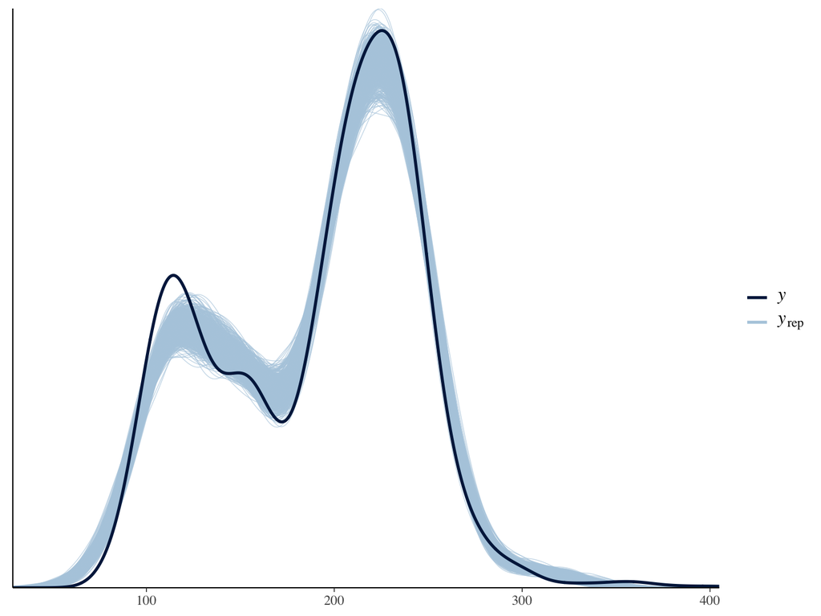

```r
pp_check_plot <- pp_check(pol_mdl, nsamples = 1000)

# Show in markdown:

pp_check_plot
```

```r
ggsave(plot = pp_check_plot, filename = '../figures/posterior_predictive_checks.png',
       width = 8, height = 6)
ggsave(plot = pp_check_plot, filename = '../figures/posterior_predictive_checks.pdf',
       width = 8, height = 6)
```

## Visualization

Compute the estimates per language:

```r
catalan <- pol_posts$b_informpol + pol_posts$`r_lang[Catalan,informpol]`
korean <- pol_posts$b_informpol + pol_posts$`r_lang[Korean,informpol]`
japanese <- pol_posts$b_informpol + pol_posts$`r_lang[Japanese,informpol]`
chinese <- pol_posts$b_informpol + pol_posts$`r_lang[Chinese,informpol]`
austrian <- pol_posts$b_informpol + pol_posts$`r_lang[Austrian,informpol]`
german <- pol_posts$b_informpol + pol_posts$`r_lang[German,informpol]`
russian <- pol_posts$b_informpol + pol_posts$`r_lang[Russian,informpol]`

# Put all into tibble:

langs <- tibble(catalan, korean, japanese, chinese, austrian, german, russian)
```

Put the posterior means and 95% credible intervals into a tibble:

```r
M <- summarize_all(langs, mean) %>% unlist() %>% as.vector()
CI_lower <- summarize_all(langs, function(x) quantile(x, 0.025)) %>%
  unlist() %>% as.vector()
CI_upper <- summarize_all(langs, function(x) quantile(x, 0.975)) %>%
  unlist() %>% as.vector()

langs <- tibble(language = colnames(langs),
                M, CI_lower, CI_upper) %>%
  mutate(language = str_to_title(language))

# Check:

langs
```

```
## # A tibble: 7 x 4
##   language     M CI_lower CI_upper
##   <chr>    <dbl>    <dbl>    <dbl>
## 1 Catalan  -4.58    -7.99   -1.43
## 2 Korean   -7.13   -12.4    -3.11
## 3 Japanese -3.33    -6.36    0.463
## 4 Chinese  -2.74    -6.04    1.53
## 5 Austrian -4.08    -7.33   -0.797
## 6 German   -4.38    -7.86   -0.908
## 7 Russian  -4.74    -9.60   -0.535
```

Get the actual means per language into there:

```r
langs <- left_join(langs, lang_avgs, by = c('language' = 'lang'))
```

Make a plot of this:

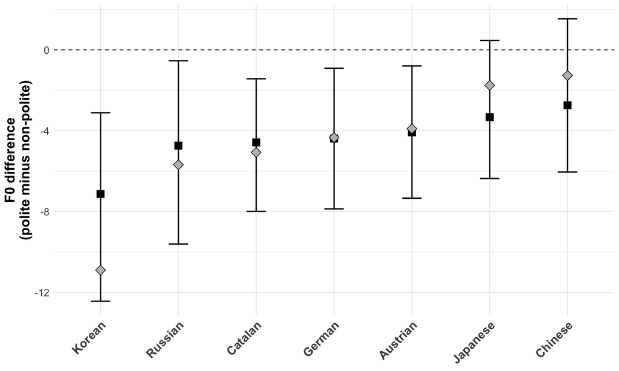

```r
# Setup astethics:

p <- langs %>% ggplot(aes(x = reorder(language, M), y = M,
                          ymin = CI_lower, ymax = CI_upper))

# Add geoms:

p <- p +
  geom_errorbar(width = 0.25, size = 0.75) +
  geom_point(shape = 15, size = 4) +
  geom_hline(mapping = aes(yintercept = 0),
             linetype = 2)

# Add descriptive averages on top of that diamond shaped:

p <- p +
  geom_point(mapping = aes(y = diff),
             shape = 23, fill = 'grey', col = 'black',
             size = 4)

# Cosmetic tweaks:

p <- p +
  ylab('F0 difference\n(polite minus non-polite)') +
  theme_minimal() +
  theme(axis.text.x = element_text(angle = 45, hjust = 1, vjust = 1,
                                   face = 'bold', size = 14),
        axis.title.y = element_text(size = 16, face = 'bold'),
        axis.text.y = element_text(size = 12),
        axis.title.x = element_blank(),
        strip.background = element_blank(),
        plot.background = element_rect(fill = 'transparent', colour = NA))

# Plot:

p
```

```r
# Save plot:

ggsave(plot = p, filename = '../figures/language_posteriors.pdf',
       width = 8, height = 5)
```

This completes this analysis.